# Ejercicio Final: Análisis Discriminante Lineal, Análisis Discriminante No Lineal, Naïve Bayes

Javier Herráez Albarrán

# Objetivo y datos

Este ejercicio consistirá en realizar un modelo que nos permita predecir la recaída o no de pacientes que han tenido cáncer de mama. Para ello contaremos con un dataset que consta de los datos recogidos de 24481 genes a 97 pacientes.

# Exploración y reprocesado

La última columna del dataset es la que indica si el paciente ha recaído o no en la enfermedad. Veremos como se distribuye.

```r
target <- colnames(cancer_df)[ncol(cancer_df)]
target
```

```
## [1] "Class"
```

```r
table(cancer_df[, target])
```

```
##
## non-relapse     relapse
##          51          46
```

Observamos que existen 46 pacientes con recaída y 51 que no. Tratamos esta columna para simplicarla.

```r
colnames(cancer_df)[ncol(cancer_df)] <- "Relapse"
levels(cancer_df$Relapse) <- c("No", "Yes")
```

Vamos a mostrar la distribución de los missing values por files, es decir, por paciente.

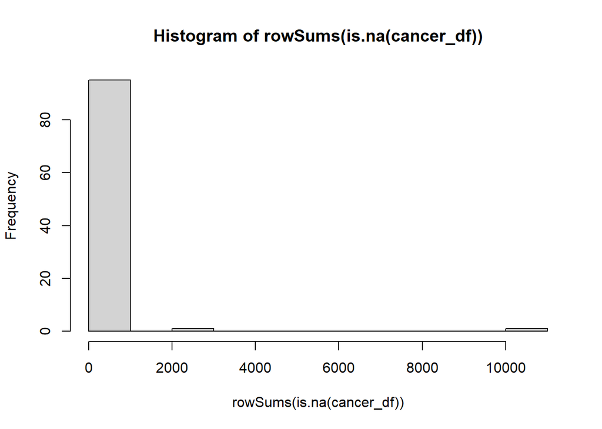

```r
hist(rowSums(is.na(cancer_df)))
```

```r
table(rowSums(is.na(cancer_df)))
```

```
##
##   293   294   295   296   297   298   300   301   302   308   309   312   318
##    57     5     3     3     1     3     1     3     1     1     1     1     1
##   319   322   324   325   326   327   333   336   340   353   377   407   431
##     1     1     1     1     2     1     1     1     1     1     1     1     1
##  2397 10896
##     1     1
```

Podemos observar que la mayoría de pacientes tienen unos 300 missings values. Hay un par de pacientes que destacan que tienen respectivamente 2397 y 10896 missings values.

Ahora hacemos lo mismo con las columnas.

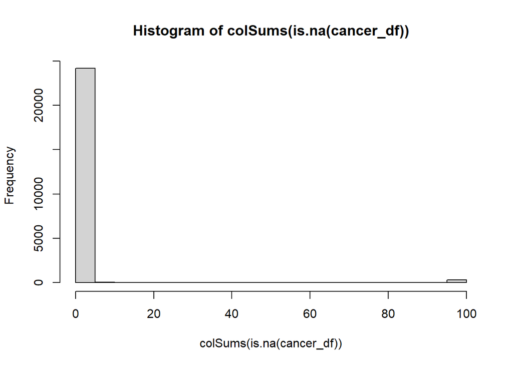

```r
hist(colSums(is.na(cancer_df)))
```

```r
table(colSums(is.na(cancer_df)))
```

```
##
##     0     1     2     3     4     5     6     7     8     9    10    11    12
## 13548  8397  1825   266    84    34    17     9     3     1     2     1     1
##    13    97
##     1   293
```

Vemos que la mayoría de columnas no tienen casi ningún missing values. sin embargo, existen 293 columnas que tienen 97 datos faltantes, es decir, que no tienen ningún dato para ningún paciente. Por lo tanto, procedemos a eliminar estas columnas.

```r
nasColumns <- sapply(cancer_df, function(x) all(is.na(x)))

cancer_df <- cancer_df[, !(nasColumns)]
table(rowSums(is.na(cancer_df)))
```

```
##
##     0     1     2     3     4     5     7     8     9    15    16    19    25
##    57     5     3     3     1     3     1     3     1     1     1     1     1
##    26    29    31    32    33    34    40    43    47    60    84   114   138
##     1     1     1     1     2     1     1     1     1     1     1     1     1
##  2104 10603
##     1     1
```

```r
table(colSums(is.na(cancer_df)))
```

```
##
##     0     1     2     3     4     5     6     7     8     9    10    11    12
## 13548  8397  1825   266    84    34    17     9     3     1     2     1     1
##    13
##     1
```

Tras ello, podemos oobservar que ahora nuestros pacientes prácticamente no tienen casi ningún missing values a excepción de los dos comentados con anterioridad.

Tras plantearlo, decidimos eliminar la observación del paciente con más de 10000 NAs y una vez hecho esto, eliminar cualquier columna que tenga algún missing value. De esta forma nos quedamos con 96 pacientes y casi 22000 genes.

```r
cancer_df <- cancer_df[!(rowSums(is.na(cancer_df)) > 10000),]
row.names(cancer_df) <- 1:nrow(cancer_df)

table(colSums(is.na(cancer_df)))
```

```
##
##     0     1     2     3     4     5     6     7     8     9    10    11    12
## 21907  1863   266    84    34    17     9     3     1     2     1     1     1
```

```r
nasColumns_2 <- sapply(cancer_df, function(x) any(is.na(x)))
cancer_df <- cancer_df[, !(nasColumns_2)]

table(colSums(is.na(cancer_df)))
```

```
##
##     0
## 21907
```

```r
genes <- cancer_df[,1:ncol(cancer_df) - 1]
```

# Regularized discriminant analysis (Shrinkage) con PCA

Vamos a tratar de crear un modelo que mediante RDA nos de solución al problema planteado inicialmente. Decidimos utilizar PCA para reducir la dimensionalidad de nuestros datos. Probamos un primer modelo que utilice tantas componentes como para tener una explicabilidad del 90% de nuestros datos. Además, utilizamos 5-fold cross-validation para entrenar el modelo y añadimos la propiedad prior para indicar que las proporciones de recaída serían del 50%.

```r
set.seed(1404)

pre <- preProcess(genes, method = c("pca"), thresh = 0.9)

rdaFitPCA <- train(Relapse ~ .,
                method = "rda",
                tuneGrid = expand.grid(gamma = seq(0.1, 1, .1), lambda = seq(0.1, 1, .1)),
                metric = "Kappa",
                data = predict(pre, cancer_df),
                trControl = trainControl(method = "cv", number = 5, classProbs = TRUE),
                preProcess = c("center", "scale"),
                prior = c(0.5, 0.5))
rdaFitPCA
```

```
## Regularized Discriminant Analysis
##
## 96 samples
## 65 predictors
##  2 classes: 'No', 'Yes'
##
## Pre-processing: centered (65), scaled (65)
## Resampling: Cross-Validated (5 fold)
## Summary of sample sizes: 77, 77, 77, 77, 76
## Resampling results across tuning parameters:
##
##   gamma  lambda  Accuracy   Kappa
##   0.1    0.1     0.5715789  0.1359587
##   0.1    0.2     0.5715789  0.1357229
##   0.1    0.3     0.5510526  0.0996187
##   0.1    0.4     0.5826316  0.1675291
##   0.1    0.5     0.6031579  0.2078894
##   0.1    0.6     0.6136842  0.2284034
##   0.1    0.7     0.6352632  0.2741420
##   0.1    0.8     0.6142105  0.2333430
##   0.1    0.9     0.6036842  0.2084253
##   0.1    1.0     0.6047368  0.2171253
##   0.2    0.1     0.5715789  0.1356681
##   0.2    0.2     0.5926316  0.1802343
##   0.2    0.3     0.5826316  0.1605616
##   0.2    0.4     0.5826316  0.1631178
##   0.2    0.5     0.6031579  0.2064668
##   0.2    0.6     0.6342105  0.2691747
##   0.2    0.7     0.6352632  0.2685397
##   0.2    0.8     0.6352632  0.2680974
##   0.2    0.9     0.6036842  0.2081862
##   0.2    1.0     0.6152632  0.2353798
##   0.3    0.1     0.5815789  0.1560083
##   0.3    0.2     0.5715789  0.1368370
##   0.3    0.3     0.5826316  0.1577045
##   0.3    0.4     0.5826316  0.1577045
##   0.3    0.5     0.5731579  0.1369246
##   0.3    0.6     0.6457895  0.2869688
##   0.3    0.7     0.6563158  0.3089134
##   0.3    0.8     0.6457895  0.2883920
```

[output cut: 60 more lines]

```
##   0.9    0.9     0.6352632  0.2655680
##   0.9    1.0     0.6247368  0.2469260
##   1.0    0.1     0.6147368  0.2165063
##   1.0    0.2     0.6352632  0.2610424
##   1.0    0.3     0.6352632  0.2627109
##   1.0    0.4     0.6352632  0.2627109
##   1.0    0.5     0.6247368  0.2405383
##   1.0    0.6     0.6563158  0.3035099
##   1.0    0.7     0.6663158  0.3251549
##   1.0    0.8     0.6557895  0.3046415
##   1.0    0.9     0.6457895  0.2858536
##   1.0    1.0     0.6352632  0.2655786
##
## Kappa was used to select the optimal model using the largest value.
## The final values used for the model were gamma = 0.4 and lambda = 0.9.
```

Vemos que para maximizar kappa se utiliza gamma = 0.4 y lambda = 0.9 para el que tiene un accuracy del 0.6668421.

# Regularized discriminant analysis (Shrinkage) con Clustering de variables

Ahora, probaremos a hacer lo mismo pero con selección de variables mediante clustering.

Lo que haremos será trasponer columnas y filas del dataset y utilizar el método PAM de clustering que toma como centros de sus grupos a un elemento de los datos. De esta manera podremos escoger estas variables (medoids) y hacer modelos de RDA con únicamente estas variables.

Primero, tomamos una muestra de nuestras variables y vemos cuantas variables vamos a seleccionar.

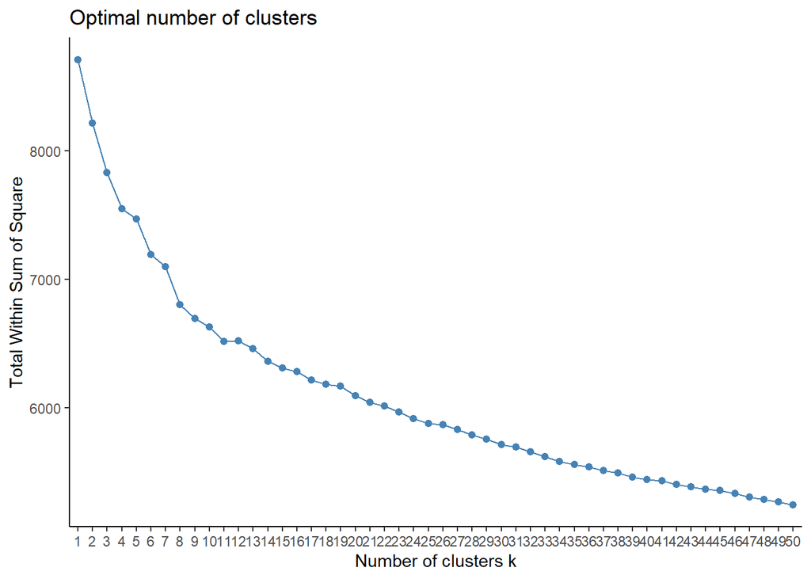

```r
genes_traspose <- as.data.frame(t(genes))

set.seed(1404)
samples <- createDataPartition(genes_traspose$`1`, p = 0.1, list = FALSE)
genes_traspose.subset  <- genes_traspose[samples, ]

fviz_nbclust(genes_traspose.subset, pam, method="wss", k.max = 50) + theme_classic() # "wss" (for total within sum of square)
```

Decidimos hacer clustering con 30 grupos, así que tomamos las 30 variables medoids y desarrollamos modelos únicamente con estas variables. Volvemos a utilizar RDA y 5-fold cross validation para entrenamiento.

```r
pm <- eclust(genes_traspose.subset, FUNcluster="pam", k = 30, hc_metric = "euclidean", hc_method = "ward.D2", graph = F)
medoids <- rownames(pm$medoids)

cancer_clustering <- cancer_df[, c(medoids, "Relapse")]

rdaFitClust <- train(Relapse ~ .,
                method = "rda",
                tuneGrid = expand.grid(gamma = seq(0.1, 1, .1), lambda = seq(0.1, 1, .1)),
                metric = "Kappa",
                data = cancer_clustering,
                trControl = trainControl(method = "cv", number = 5, classProbs = TRUE),
                preProcess = c("center", "scale")
                )
rdaFitClust
```

```
## Regularized Discriminant Analysis
##
## 96 samples
## 30 predictors
##  2 classes: 'No', 'Yes'
##
## Pre-processing: centered (30), scaled (30)
## Resampling: Cross-Validated (5 fold)
## Summary of sample sizes: 77, 77, 76, 77, 77
## Resampling results across tuning parameters:
##
##   gamma  lambda  Accuracy   Kappa
##   0.1    0.1     0.5931579  0.1810241
##   0.1    0.2     0.6247368  0.2418512
##   0.1    0.3     0.6457895  0.2864921
##   0.1    0.4     0.6257895  0.2428186
##   0.1    0.5     0.6052632  0.2038818
##   0.1    0.6     0.5947368  0.1821952
##   0.1    0.7     0.5736842  0.1376259
##   0.1    0.8     0.5736842  0.1373926
##   0.1    0.9     0.5736842  0.1383996
##   0.1    1.0     0.5736842  0.1400700
##   0.2    0.1     0.6147368  0.2221327
##   0.2    0.2     0.6252632  0.2411426
##   0.2    0.3     0.6357895  0.2629461
##   0.2    0.4     0.6152632  0.2191801
##   0.2    0.5     0.6152632  0.2191801
##   0.2    0.6     0.5836842  0.1521177
##   0.2    0.7     0.5731579  0.1296960
##   0.2    0.8     0.5626316  0.1091826
##   0.2    0.9     0.5626316  0.1145150
##   0.2    1.0     0.5731579  0.1383671
##   0.3    0.1     0.6247368  0.2380768
##   0.3    0.2     0.6352632  0.2583544
##   0.3    0.3     0.6463158  0.2809011
##   0.3    0.4     0.6357895  0.2581998
##   0.3    0.5     0.6357895  0.2545172
##   0.3    0.6     0.6147368  0.2116217
##   0.3    0.7     0.6042105  0.1911177
##   0.3    0.8     0.5621053  0.1080900
```

[output cut: 60 more lines]

```
##   0.9    0.9     0.6678947  0.3208616
##   0.9    1.0     0.6573684  0.3001163
##   1.0    0.1     0.6468421  0.2750449
##   1.0    0.2     0.6363158  0.2545409
##   1.0    0.3     0.6363158  0.2545409
##   1.0    0.4     0.6468421  0.2767335
##   1.0    0.5     0.6573684  0.2989343
##   1.0    0.6     0.6573684  0.2989343
##   1.0    0.7     0.6573684  0.2989343
##   1.0    0.8     0.6573684  0.2989343
##   1.0    0.9     0.6468421  0.2784209
##   1.0    1.0     0.6468421  0.2784209
##
## Kappa was used to select the optimal model using the largest value.
## The final values used for the model were gamma = 0.8 and lambda = 0.4.
```

Los gamma y lambda para maximizar Kappa son, respectivamente, 0.8 y 0.4 que da un accuracy de 0.6884211.

Por último, vamos a intentar minimizar los falsos negativos, es decir, casos donde el modelo predice que no existe recaída pero en realidad sí que la hay. Es difícil, valorar cuanto puede valer acertar y errar en nuestro modelo, pero lo valoraremos de la siguiente manera: acertar la predicción no supone coste ninguno, mientras que le damos coste a los errores de manera que un falso negativo es un 50% más costoso que un falso positivo.

```r
cost.unit <- c(0, 1, 1.5, 0)
cost.i = matrix(NA, nrow = 50, ncol = 10)
PnoRno = matrix(NA, nrow = 50, ncol = 10)
PnoRyes = matrix(NA, nrow = 50, ncol = 10)
PyesRno = matrix(NA, nrow = 50, ncol = 10)
PyesRyes = matrix(NA, nrow = 50, ncol = 10)
accuracy = matrix(NA, nrow = 50, ncol = 10)

# 50 replicates for training/testing sets for each of the 10 values of threshold
j <- 0
for (threshold in seq(0.05,0.5,0.05)){
  j <- j + 1
  cat(j)
  for(i in 1:50){
    d <- createDataPartition(cancer_clustering$Relapse, p = 0.7, list = FALSE)

    train <- cancer_clustering[d,]
    test  <- cancer_clustering[-d,]

    rdaFit <- train(Relapse ~ ., data = train, method = "rda",
                    tuneGrid = data.frame(gamma = 0.8, lambda = 0.4),
                    preProcess = c("center", "scale"),
                    trControl = trainControl(method = "none", classProbs = TRUE))

    rdaProb = predict(rdaFit, test, type="prob")
    rdaPred = rep("No", nrow(test))
    rdaPred[which(rdaProb[,2] > threshold)] = "Yes"

    CM = confusionMatrix(factor(rdaPred), test$Relapse)
    accuracy[i,j] <- unname(CM$overall['Accuracy'])

    CM <- CM$table
    cost = sum(as.vector(CM)*cost.unit)/sum(CM)

    cost.i[i,j] <- cost
    PnoRno[i,j] <- CM[1,1]/sum(CM)
    PnoRyes[i,j] <- CM[1,2]/sum(CM)
    PyesRno[i,j] <- CM[2,1]/sum(CM)
    PyesRyes[i,j] <- CM[2,2]/sum(CM)

  }
}
```

```
## 12345678910
```

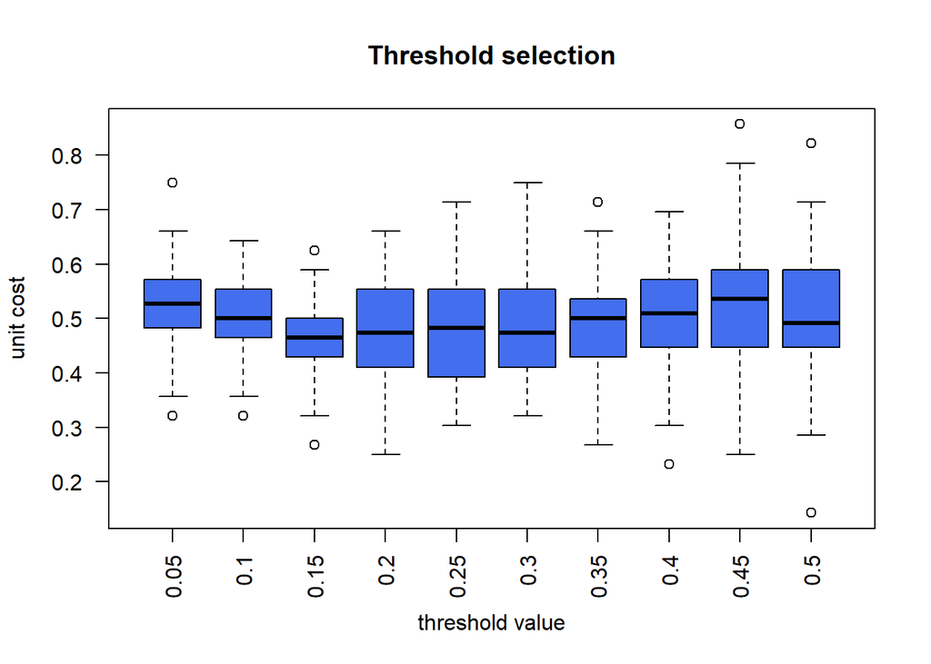

```r
boxplot(cost.i, main = "Threshold selection",
        ylab = "unit cost",
        xlab = "threshold value",
        names = seq(0.05,0.5,0.05),col="royalblue2",las=2)
```

Vemos que podemos tomar como threshold 0.2, es decir, a partir de que la probabilidad de recaída del paciente sea del 20%, lo trataremos como que sí que existe esta recaída.

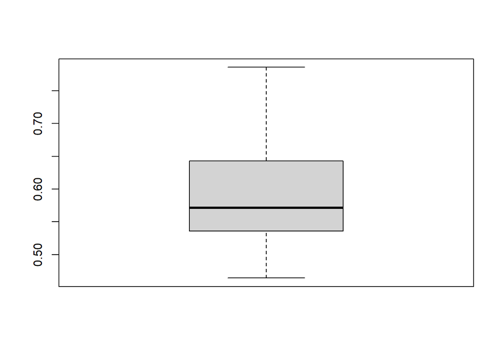

```r
boxplot(accuracy[,4])
```

```r
mean(accuracy[,4])
```

```
## [1] 0.5964286
```

Vemos que con esta condición tendríamos un accuracy de media del 60%. Además, podemos ver como se van a distribuir nuestras predicciones:

```r
dist <- matrix(c(mean(PnoRno[,4]), mean(PyesRno[,4]), mean(PnoRyes[,4]), mean(PyesRyes[,4])), nrow=2, ncol=2)
colnames(dist) <- c("Ref No", "Ref Yes")
rownames(dist) <- c("Pred No", "Pred Yes")
dist
```

```
##             Ref No   Ref Yes
## Pred No  0.2792857 0.1471429
## Pred Yes 0.2564286 0.3171429
```